### Classification Model Metrics

#### Overview

We can use machine learning to predict labels on documents using a classification model. For both types of prediction questions, we develop a learner or model to describe the relationship between a target or outcome variable and our input features; what is different about a classification model is the nature of that outcome.

- A regression model predicts a numeric or continuous value.
- A classification model predicts a class label or group membership.

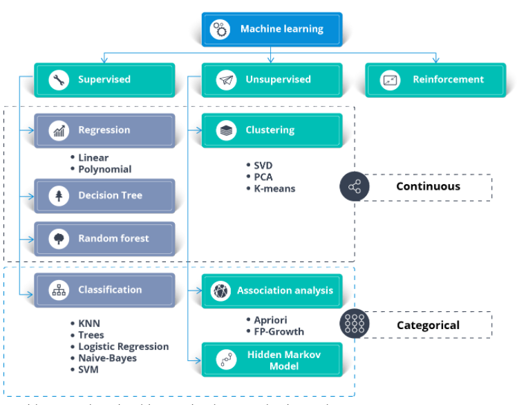

#### Packages

```r
library(plyr)
library(knitr)
library(readr)
library(tidyverse)
library(tidymodels)
library(DT)
library(dplyr)
library(textrecipes)
library(readr)

set.seed(1234)
```

#### Data

Let’s consider the data set of consumer complaints submitted to the US Consumer Finance Protection Bureau.

**Unzip dataset using plyr package**

```r
# temporary directory

library(plyr)
my_dir <- "/Users/maria/OneDrive - City University of New York/Documents/R/DATA 607/Projects/Project # 4/data"

zip_file <- list.files(path = my_dir, pattern = "*.zip", full.names = TRUE)

ldply(.data = zip_file, .fun = unzip, exdir = my_dir)
```

```
##                                                                                                                                        V1
## 1 /Users/maria/OneDrive - City University of New York/Documents/R/DATA 607/Projects/Project # 4/data/WA_Fn-UseC_-Telco-Customer-Churn.csv
## 2                       /Users/maria/OneDrive - City University of New York/Documents/R/DATA 607/Projects/Project # 4/data/complaints.csv
```

2.- Load Data

```r
library(readr)

complaints <- read_csv("data/complaints.csv")
```

This data set contains a text field with the complaint, along with information regarding what it was for, how and when it was filed, and the response from the bureau.

```r
library(dplyr)
glimpse(complaints)
```

```
## Rows: 2,067,107
## Columns: 18
## $ `Date received`                <date> 2019-09-24, 2019-09-19, 2019-11-08, 20~
## $ Product                        <chr> "Debt collection", "Credit reporting, c~
## $ `Sub-product`                  <chr> "I do not know", "Credit reporting", "I~
## $ Issue                          <chr> "Attempts to collect debt not owed", "I~
## $ `Sub-issue`                    <chr> "Debt is not yours", "Information belon~
## $ `Consumer complaint narrative` <chr> "transworld systems inc. \nis trying to~
## $ `Company public response`      <chr> NA, "Company has responded to the consu~
## $ Company                        <chr> "TRANSWORLD SYSTEMS INC", "Experian Inf~
## $ State                          <chr> "FL", "PA", "NC", "AZ", "TX", "TX", "MD~
## $ `ZIP code`                     <chr> "335XX", "15206", "275XX", "85254", "79~
## $ Tags                           <chr> NA, NA, NA, NA, NA, "Older American", N~
## $ `Consumer consent provided?`   <chr> "Consent provided", "Consent not provid~
## $ `Submitted via`                <chr> "Web", "Web", "Web", "Referral", "Web",~
## $ `Date sent to company`         <date> 2019-09-24, 2019-09-20, 2019-11-08, 20~
## $ `Company response to consumer` <chr> "Closed with explanation", "Closed with~
## $ `Timely response?`             <chr> "Yes", "Yes", "Yes", "Yes", "Yes", "Yes~
## $ `Consumer disputed?`           <chr> "N/A", "N/A", "N/A", "N/A", "N/A", "N/A~
## $ `Complaint ID`                 <dbl> 3384392, 3379500, 3433198, 3255455, 319~
```

#### Tidy Data

Classification is the method of predicting the class of a given input data point. Classification problems are common in machine learning and they fall under the Supervised learning method.

Under classification we have 2 types:

- Binary Classification
- Multi-Class Classification

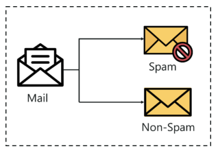

**I will build classification model to predict what type of financial product the complaints are referring to, i.e., a label or categorical variable.**

```r
# lets take a look at the data "consumer complain narrative"

head(complaints$`Consumer complaint narrative`)
```

```
## [1] "transworld systems inc. \nis trying to collect a debt that is not mine, not owed and is inaccurate."
## [2] NA
## [3] "Over the past 2 weeks, I have been receiving excessive amounts of telephone calls from the company listed in this complaint. The calls occur between XXXX XXXX and XXXX XXXX to my cell and at my job. The company does not have the right to harass me at work and I want this to stop. It is extre…
## [4] NA
## [5] "I am a victim of identity theft. My personal information was compromised and fraudulent charges were included on my accounts without my consent or authorization. On on all accounts I sent this the reporting companies my letter which explained in detail what was fraudulent and needed removal …
## [6] NA
```

```r
library(stringr)
complaints$`Consumer complaint narrative` %>%
  str_extract_all("\\{\\$[0-9\\.]*\\}") %>%
  compact() %>%
  head()
```

```
## [[1]]
## character(0)
##
## [[2]]
## [1] NA
##
## [[3]]
## character(0)
##
## [[4]]
## [1] NA
##
## [[5]]
## character(0)
##
## [[6]]
## [1] NA
```

#### Model

This data set includes more possible predictors than the text alone, but for this first model we will only use the text variable ‘consumer_complaint_narrative’

Factor outcome variable ‘product’ with 2 levels

1- “credit” 2- “other”

```r
library(tidymodels)

#create levels

complaints2class <- complaints %>%
  mutate(Product = factor(if_else(
    Product == paste("Credit Reporting, credit repair services,", "or other personal consumer reports"),
    "Credit", "Other"
  )))
```

```r
complaints_split <- initial_split(complaints2class, strata = Product)

complaints_train <- training(complaints_split)
complaints_test <- testing(complaints_split)
```

```r
dim(complaints_train)
```

```
## [1] 1550331      18
```

```r
dim(complaints_test)
```

```
## [1] 516776     18
```

**Recipes Package**

Recipes allows to create a specification of preprocessing steps we want to perform.

```r
complaints_rec <- complaints %>%
  recipe(Product ~ `Consumer complaint narrative`, data = complaints_train)
```

**Text Recipes**

I will use **textrecipes** to handle the ‘consumer_complaint_narrative’

```r
library(textrecipes)

complaints_rec <- complaints_rec %>%
  step_tokenize(`Consumer complaint narrative`) %>%
  step_tokenfilter(`Consumer complaint narrative`, max_tokens = 1e3) %>%
  step_tfidf(`Consumer complaint narrative`)
```

```r
complaint_wf <- workflow() %>%
  add_recipe(complaints_rec)
```

```r
library(discrim)

nb_spec <- naive_Bayes() %>%
  set_mode("classification") %>%
  set_engine("naivebayes")

nb_spec
```

```
## Naive Bayes Model Specification (classification)
##
## Computational engine: naivebayes
```

#### Evaluation

I will use resampling methods to evaluate our model Each of these splits contains information about how to create cross-validation folds

```r
set.seed(234)

complaints_folds <- vfold_cv(complaints_train)

complaints_folds
```

```
## #  10-fold cross-validation
## # A tibble: 10 x 2
##    splits                   id
##    <list>                   <chr>
##  1 <split [1395297/155034]> Fold01
##  2 <split [1395298/155033]> Fold02
##  3 <split [1395298/155033]> Fold03
##  4 <split [1395298/155033]> Fold04
##  5 <split [1395298/155033]> Fold05
##  6 <split [1395298/155033]> Fold06
##  7 <split [1395298/155033]> Fold07
##  8 <split [1395298/155033]> Fold08
##  9 <split [1395298/155033]> Fold09
## 10 <split [1395298/155033]> Fold10
```

**resampling estimates of performance**

```r
nb_wf <- workflow() %>%
  add_recipe(complaints_rec) %>%
  add_model(nb_spec)

nb_wf
```

```
## == Workflow ====================================================================
## Preprocessor: Recipe
## Model: naive_Bayes()
##
## -- Preprocessor ----------------------------------------------------------------
## 3 Recipe Steps
##
## * step_tokenize()
## * step_tokenfilter()
## * step_tfidf()
##
## -- Model -----------------------------------------------------------------------
## Naive Bayes Model Specification (classification)
##
## Computational engine: naivebayes
```

```r
library(naivebayes)

nb_rs <- fit_resamples(
  nb_wf,
  complaints_folds,
  control = control_resamples(save_pred = TRUE)
)
```

```r
nb_rs_metrics <- collect_metrics(nb_rs)

nb_rs_predictions <- collect_predictions(nb_rs)
```

```r
nb_rs_metrics
```

[output not shown]

```r
nb_rs_predictions %>%
  group_by(id) %>%
  roc_curve(truth = product, .pred_Credit) %>%
  autoplot() +
  labs(
    color = NULL,
    title = "ROC curve for US Consumer Finance Complaints",
    subtitle = "Each resample fold is shown in a different color"
  )
```

[output not shown]